# E-commerce data EDA for Customer Behavior Analysis

# 8. Analysis of the Dependent variable (Churn) vs Independent variables

Until now we've looked into the numeric variables, their missing data, duplicates, distribution, and outliers. A key part of the customer behaviour data is to understand which "behaviours" aka idependent varialbes in our dataset can help us predict customers deciding to stop using the product, aka "churn".

Another variable that we haven't analysed yet is the location code, but we might be able to find value in comparing it with the churn and finding out any potential correlations.

```python
cb_df.head(2).T
```

|  | 2 | 3 |
| --- | --- | --- |
| account_length | 137 | 84 |
| location_code | 415 | 408 |
| user_id | 3581921 | 3759999 |
| credit_card_info_save | no | yes |
| push_status | no | no |
| add_to_wishlist | 0 | 0 |
| desktop_sessions | 243 | 299 |
| app_sessions | 41 | 51 |
| desktop_transactions | 10 | 5 |
| total_product_detail_views | 114 | 71 |
| session_duration | 121 | 62 |
| promotion_clicks | 110 | 88 |
| avg_order_value | 162.6 | 196.9 |
| sale_product_views | 104 | 89 |
| discount_rate_per_visited_products | 7.32 | 8.86 |
| product_detail_view_per_app_session | 12.2 | 6.6 |
| app_transactions | 5 | 7 |
| add_to_cart_per_session | 3.29 | 1.78 |
| customer_service_calls | 0 | 2 |
| churn | 0 | 0 |

```python
print(cb_df['churn'].value_counts(normalize=True))
```

```
churn
0    0.835369
1    0.164631
Name: proportion, dtype: float64
```

```python
# Group the numerical variables by the churn variable and calculate descriptive statistics
for col in numeric_columns:
    if col != 'churn':
        print(f"\nDescriptive statistics for {col} by churn:")
        print(cb_df.groupby('churn')[col].describe())
```

```
Descriptive statistics for account_length by churn:
        count        mean        std   min   25%    50%    75%    max
churn
0      1710.0  100.542690  40.017597   3.0  73.0  100.0  127.0  243.0
1       337.0  102.575668  39.182886  13.0  76.0  102.0  127.0  225.0

Descriptive statistics for add_to_wishlist by churn:
        count      mean        std  min  25%  50%   75%   max
churn
0      1710.0  8.396491  13.860485  0.0  0.0  0.0  21.0  50.0
1       337.0  5.623145  12.433770  0.0  0.0  0.0   0.0  48.0

Descriptive statistics for desktop_sessions by churn:
        count        mean        std   min    25%    50%    75%    max
churn
0      1710.0  175.970760  50.247897   3.0  143.0  179.0  212.0  316.0
1       337.0  200.869436  68.705467  47.0  145.0  199.0  262.0  337.0

Descriptive statistics for app_sessions by churn:
        count       mean        std  min   25%   50%   75%   max
churn
0      1710.0  29.917544   8.551820  0.0  24.0  30.0  36.0  54.0
1       337.0  34.148368  11.680083  8.0  25.0  34.0  44.0  57.0

Descriptive statistics for desktop_transactions by churn:
        count       mean       std  min   25%   50%   75%   max
churn
0      1710.0  16.916374  4.275821  3.0  14.0  17.0  20.0  30.0
1       337.0  17.712166  4.395303  6.0  15.0  18.0  21.0  31.0

Descriptive statistics for total_product_detail_views by churn:
        count        mean        std   min   25%    50%    75%    max
churn
0      1710.0  100.084211  19.209051  35.0  88.0  100.0  113.0  163.0
1       337.0  101.329377  19.879731  47.0  88.0  102.0  115.0  165.0

Descriptive statistics for session_duration by churn:
        count        mean        std   min     25%    50%    75%    max
churn
0      1710.0  198.963158  50.151944  31.0  164.25  200.0  233.0  349.0
```

[output cut: 34 more lines]

```
churn
0      1710.0  4.698830  2.310317  0.0  3.0  4.0  6.0  19.0
1       337.0  4.216617  2.281647  2.0  3.0  4.0  5.0  15.0

Descriptive statistics for add_to_cart_per_session by churn:
        count      mean       std   min     25%   50%   75%  max
churn
0      1710.0  2.754503  0.757007  0.00  2.2775  2.75  3.24  5.1
1       337.0  2.906647  0.732245  1.05  2.4000  2.94  3.46  5.4

Descriptive statistics for customer_service_calls by churn:
        count      mean       std  min  25%  50%  75%  max
churn
0      1710.0  1.714620  1.408146  0.0  0.0  2.0  3.0  8.0
1       337.0  2.658754  1.966805  0.0  2.0  3.0  4.0  9.0
```

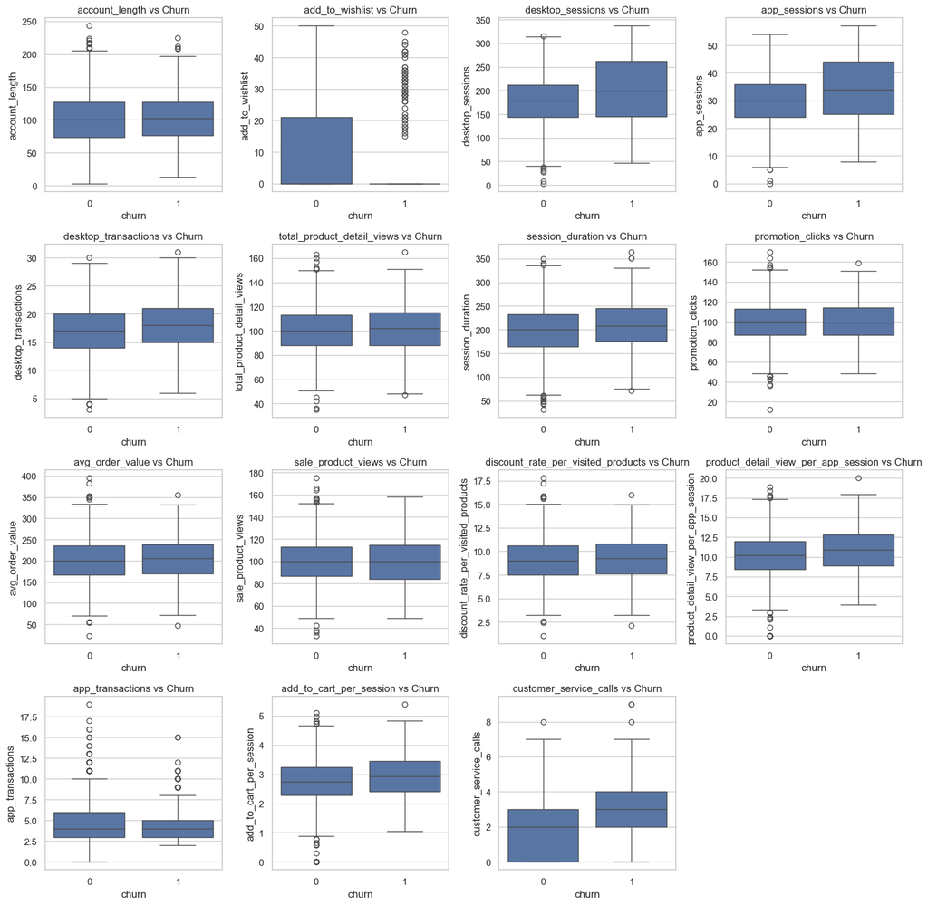

```python
plt.figure(figsize=(15, 15))

for i, col in enumerate(numeric_columns):
    if col != 'churn':
        plt.subplot(4, 4, i + 1)   # 4x4 = 16 ô, đủ chỗ
        sns.boxplot(x='churn', y=col, data=cb_df)
        plt.title(f'{col} vs Churn')

plt.tight_layout()
plt.show()
```

```python
from scipy.stats import chi2_contingency
# Chi-square test
contingency_table = pd.crosstab(cb_df['location_code'], cb_df['churn'])
chi2, p, dof, expected = chi2_contingency(contingency_table)
print(f"Chi-square test statistic: {chi2}, p-value: {p}")
```

```
Chi-square test statistic: 1.755567320384775, p-value: 0.41570323105375917
```

```python
import pandas as pd
# Use one-hot encoding for categorical variables
cb_df = pd.get_dummies(cb_df, columns=['credit_card_info_save', 'push_status', 'location_code'], drop_first=True)
cb_df.info()
```

```
<class 'pandas.core.frame.DataFrame'>
Index: 2047 entries, 2 to 3332
Data columns (total 21 columns):
 #   Column                               Non-Null Count  Dtype
---  ------                               --------------  -----
 0   account_length                       2047 non-null   int64
 1   user_id                              2047 non-null   int64
 2   add_to_wishlist                      2047 non-null   int64
 3   desktop_sessions                     2047 non-null   int64
 4   app_sessions                         2047 non-null   int64
 5   desktop_transactions                 2047 non-null   int64
 6   total_product_detail_views           2047 non-null   int64
 7   session_duration                     2047 non-null   int64
 8   promotion_clicks                     2047 non-null   int64
 9   avg_order_value                      2047 non-null   float64
 10  sale_product_views                   2047 non-null   int64
 11  discount_rate_per_visited_products   2047 non-null   float64
 12  product_detail_view_per_app_session  2047 non-null   float64
 13  app_transactions                     2047 non-null   int64
 14  add_to_cart_per_session              2047 non-null   float64
 15  customer_service_calls               2047 non-null   int64
 16  churn                                2047 non-null   int64
 17  credit_card_info_save_yes            2047 non-null   bool
 18  push_status_yes                      2047 non-null   bool
 19  location_code_415                    2047 non-null   bool
 20  location_code_510                    2047 non-null   bool
dtypes: bool(4), float64(4), int64(13)
memory usage: 295.9 KB
```

```python
# Compute correlations

correlation_matrix = cb_df.corr()
print(correlation_matrix['churn'].sort_values(ascending=False))
```

```
churn                                  1.000000
credit_card_info_save_yes              0.241808
customer_service_calls                 0.225397
desktop_sessions                       0.169487
app_sessions                           0.169275
product_detail_view_per_app_session    0.074796
add_to_cart_per_session                0.074757
session_duration                       0.070966
desktop_transactions                   0.068573
avg_order_value                        0.024200
discount_rate_per_visited_products     0.024192
total_product_detail_views             0.023905
user_id                                0.020291
account_length                         0.018910
location_code_510                      0.010762
promotion_clicks                      -0.001448
sale_product_views                    -0.009115
location_code_415                     -0.028283
add_to_wishlist                       -0.075246
app_transactions                      -0.077367
push_status_yes                       -0.088684
Name: churn, dtype: float64
```

```python
# Define features (X) and target (y)
X = cb_df.drop('churn', axis=1)  # independent variables
y = cb_df['churn']  # dependent variable

# Split the data into training and test sets
X_train, X_test, y_train, y_test = train_test_split(X, y, test_size=0.2, random_state=42)

# Initialize DecisionTree
model = DecisionTreeClassifier(random_state=42)

# Fit the model
model.fit(X_train, y_train)

# Predict on test data
y_pred_dt = model.predict(X_test)

# Evaluate the Decision Tree model
print("Decision Tree Classifier:")
print(classification_report(y_test, y_pred_dt))
```

```
Decision Tree Classifier:
              precision    recall  f1-score   support

           0       0.95      0.95      0.95       340
           1       0.77      0.76      0.76        70

    accuracy                           0.92       410
   macro avg       0.86      0.86      0.86       410
weighted avg       0.92      0.92      0.92       410
```

```python
# Initialize RandomForest
model1 = RandomForestClassifier(random_state=42)

# Fit the model
model1.fit(X_train, y_train)

# Predict on test data
y_pred_rf = model1.predict(X_test)

# Evaluate the RandomForest model
print("RandomForest Classifier:")
print(classification_report(y_test, y_pred_rf))
```

```
RandomForest Classifier:
              precision    recall  f1-score   support

           0       0.94      0.99      0.96       340
           1       0.90      0.67      0.77        70

    accuracy                           0.93       410
   macro avg       0.92      0.83      0.87       410
weighted avg       0.93      0.93      0.93       410
```

```python
# Feature importance from RandomForest
importances = model1.feature_importances_
feature_names = X.columns
feature_importances = pd.DataFrame({'Feature': feature_names, 'Importance': importances})
feature_importances = feature_importances.sort_values(by='Importance', ascending=False)
print(feature_importances)
```

```
                                Feature  Importance
3                      desktop_sessions    0.155631
15               customer_service_calls    0.138204
4                          app_sessions    0.106852
7                      session_duration    0.066338
16            credit_card_info_save_yes    0.055305
5                  desktop_transactions    0.049162
14              add_to_cart_per_session    0.043696
9                       avg_order_value    0.039790
13                     app_transactions    0.038808
10                   sale_product_views    0.037876
12  product_detail_view_per_app_session    0.037599
11   discount_rate_per_visited_products    0.036907
6            total_product_detail_views    0.035277
0                        account_length    0.033566
1                               user_id    0.033544
8                      promotion_clicks    0.031643
2                       add_to_wishlist    0.025854
17                      push_status_yes    0.021952
18                    location_code_415    0.006539
19                    location_code_510    0.005455
```